# Client Report - Project 05

- Show All Code
- Hide All Code

Course DS 250

Author

Tad Decker

## Elevator pitch

Through cleaning and organizing the information given, I was able to create a model that can predict whether an individual’s income is above or below $50,000, although with not a very high accuracy.

**Read and format project data**

```python
df = pd.read_csv("https://raw.githubusercontent.com/fivethirtyeight/data/master/star-wars-survey/StarWars.csv", encoding='unicode_escape')
```

## 1. Clean table

Shorten the column names and clean them up for easier use with pandas. Provide a table or list that exemplifies how you fixed the names.

The following list gives the list of each column, and associated qualities.

**Clean data**

```python
# Create an empty dataframe
df2 = pd.DataFrame()

# Drop the first row: they're just column headers.
df = df.iloc[1: , :]

# Don't save Id, we don't care about it

# seen_film (Seen ANY of the star wars movies)
df2['seen_film'] = df['Have you seen any of the 6 films in the Star Wars franchise?'].map(
  lambda x: True if x == "Yes" else False if x == "No" else False )

# isFan
df2['is_fan'] = df['Do you consider yourself to be a fan of the Star Wars film franchise?'].map(
  lambda x: True if x == "Yes" else False if x == "No" else False )

# Episode 1
df2['ep_1'] = df['Which of the following Star Wars films have you seen? Please select all that apply.'].map(
  lambda x: True if x == "Star Wars: Episode I  The Phantom Menace" else False
)

# Episode 2
df2['ep_2'] = df['Unnamed: 4'].map(
  lambda x: True if x == "Star Wars: Episode II  Attack of the Clones" else False
)

# Episode 3
df2['ep_3'] = df['Unnamed: 5'].map(
  lambda x: True if x == "Star Wars: Episode III  Revenge of the Sith" else False
)

# Episode 4
df2['ep_4'] = df['Unnamed: 6'].map(
  lambda x: True if x == "Star Wars: Episode IV  A New Hope" else False
)

# Episode 5
df2['ep_5'] = df['Unnamed: 7'].map(
  lambda x: True if x == "Star Wars: Episode V The Empire Strikes Back" else False
)

# Episode 6
df2['ep_6'] = df['Unnamed: 8'].map(
  lambda x: True if x == "Star Wars: Episode VI Return of the Jedi" else False
)

# Episode rank. Replace nan values with 3

# Episode 1 rank
df2['ep_1_rank'] = df['Please rank the Star Wars films in order of preference with 1 being your favorite film in the franchise and 6 being your least favorite film.'].fillna(3).astype(int)

# Episode 2 rank
df2['ep_2_rank'] = df['Unnamed: 10'].fillna(3).astype(int)

# Episode 3 rank
df2['ep_3_rank'] = df['Unnamed: 11'].fillna(3).astype(int)

# Episode 4 rank
df2['ep_4_rank'] = df['Unnamed: 12'].fillna(3).astype(int)

# Episode 5 rank
df2['ep_5_rank'] = df['Unnamed: 13'].fillna(3).astype(int)

# Episode 6 rank
df2['ep_6_rank'] = df['Unnamed: 14'].fillna(3).astype(int)

def shortenOpinion(opinion):
  if (opinion == "Very favorably"):
    return "5"
  elif (opinion == "Somewhat favorably"):
    return "4"
  elif (opinion == "Neither favorably nor unfavorably (neutral)"):
    return "3"
  elif (opinion == "Somewhat unfavorably"):
    return "2"
  elif (opinion == "Very unfavorably"):
    return "1"
  else: # "Unfamiliar (N/A)"
    return "0"

# Character favorability
df2['han'] = df['Please state whether you view the following characters favorably, unfavorably, or are unfamiliar with him/her.'].map(lambda x: shortenOpinion(x))
df2['luke'] = df['Unnamed: 16'].map(lambda x: shortenOpinion(x))
df2['leia'] = df['Unnamed: 17'].map(lambda x: shortenOpinion(x))
df2['anakin'] = df['Unnamed: 18'].map(lambda x: shortenOpinion(x))
df2['obi_wan'] = df['Unnamed: 19'].map(lambda x: shortenOpinion(x))
df2['palp'] = df['Unnamed: 20'].map(lambda x: shortenOpinion(x))
df2['vader'] = df['Unnamed: 21'].map(lambda x: shortenOpinion(x))
df2['lando'] = df['Unnamed: 22'].map(lambda x: shortenOpinion(x))
df2['boba'] = df['Unnamed: 23'].map(lambda x: shortenOpinion(x))
df2['c-3p0'] = df['Unnamed: 24'].map(lambda x: shortenOpinion(x))
df2['r2_d2'] = df['Unnamed: 25'].map(lambda x: shortenOpinion(x))
df2['jar_jar'] = df['Unnamed: 26'].map(lambda x: shortenOpinion(x))
df2['padme'] = df['Unnamed: 27'].map(lambda x: shortenOpinion(x))
df2['yoda'] = df['Unnamed: 28'].map(lambda x: shortenOpinion(x))

# Who shot first?
# Fill nan values with "I don't understand this question"
df2['first'] = df['Which character shot first?'].fillna("I don't understand this question").astype(str)

# Expanded universe?
# If nan, replace with "No"
df2['eu'] = df['Are you familiar with the Expanded Universe?'].fillna('No').astype(str)

# Ignore star trek column

# Change column titles; we'll modify them more later
# If value is nan, assign to one of the values randomly.
df2['gender'] = df['Gender'].fillna(random.choice(["Male", "Female"]))
df2['age'] = df['Age'].fillna(random.choice(['18-29', '30-44', '> 60', '45-60']))
df2['income'] = df['Household Income'].fillna(random.choice(['$0 - $24,999', '$25,000 - $49,999', '$50,000 - $99,999', '$100,000 - $149,999', '$150,000+']))
df2['education'] = df['Education'].fillna(random.choice(['High school degree', 'Some college or Associate degree', 'Bachelor degree', 'Graduate degree', 'Less than high school degree']))
df2['location'] = df['Location (Census Region)'].fillna(random.choice(['South Atlantic', 'Pacific', 'Mountain', 'East North Central', 'West South Central', 'New England', 'Middle Atlantic', 'West North Central', 'East South Central']))

df2.info()
```

```
<class 'pandas.core.frame.DataFrame'>
RangeIndex: 1186 entries, 1 to 1186
Data columns (total 35 columns):
 #   Column     Non-Null Count  Dtype
---  ------     --------------  -----
 0   seen_film  1186 non-null   bool
 1   is_fan     1186 non-null   bool
 2   ep_1       1186 non-null   bool
 3   ep_2       1186 non-null   bool
 4   ep_3       1186 non-null   bool
 5   ep_4       1186 non-null   bool
 6   ep_5       1186 non-null   bool
 7   ep_6       1186 non-null   bool
 8   ep_1_rank  1186 non-null   int32
 9   ep_2_rank  1186 non-null   int32
```

[output cut: 27 more lines]

## 2. Clean and format data

Clean and format the data so that it can be used in a machine learning model. As you format the data, you should complete each item listed below. In your final report provide example(s) of the reformatted data with a short description of the changes made.

1. Filter the dataset to respondents that have seen at least one film.

We removed every respondent that HAS NOT seen at least ONE film. Some of the entries marked themselves as “Yes”, though they did not mark any of the films as seen, so we dropped those as well.

**Filter dataset**

```python
# 1186

df2 = df2[(df2['seen_film'] == True) & (df2[['ep_1', 'ep_2', 'ep_3', 'ep_4', 'ep_5', 'ep_6']].any(axis=1))]

(len(df2.index) / 1186)

male_seen = df2[df2['gender'] == 'Male']
male_total = df[df['Gender'] == 'Male']
(len(male_seen.index) / len(male_total.index))
```

```
0.8490945674044266
```

2. Create a new column that converts the age ranges to a single number. Drop the age range categorical column.

Next, we converted the value of each rangeto a single number, to make it a quantitative value. I took the lowest age in range, so “18-29” became 18, “30-44” became 30, and so forth.

**Convert age ranges to single number. Drop age range categorical column.**

```python
# Take lowest age in range
df2['age_new'] = df2['age'].map(
    lambda x: 18 if x == "18-29" else 30 if x == "30-44" else 45 if x == '45-60' else 60 if x == "> 60" else 39  # nan values go to average age, 39
  )
# Remove age column
df2 = df2.drop('age', axis=1)
```

3. Create a new column that converts the education groupings to a single number. Drop the school categorical column

I changed the education groupings to a single number, and named it “education_new”, in numerical order. “Less than high school degree” is 0, while “Graduate degree” is 4.

**Convert education to single number. Drop school categorical column.**

```python
# Assign values in ascending order
df2['education_new'] = df2['education'].map(
    lambda x: 0 if x == "Less than high school degree" else 1 if x == "High school degree" else 2 if x == 'Some college or Associate degree' else 3 if x == "Bachelor degree" else 4 if x == "Graduate degree" else 0 # Assume High school if nan (most people graduate from high school?)
  )
# Remove education column
df2 = df2.drop('education', axis=1)
```

4. Create a new column that converts the income ranges to a single number. Drop the income range categorical column.

When converting the categories, I used the median value of each range. “$0 = $24,999” became 12,500, “$25,000 - $49,999” became 37,500, and so forth.

**Convert income ranges to single number. Drop income range categorical column**

```python
# Assigne income as halfway of each range
df2['income_new'] = df2['income'].map(
    lambda x:
      12500 if x == "$0 - $24,999" else 37500 if x == "$25,000 - $49,999" else 75000 if x == "$50,000 - $99,999" else 125000 if x == "$100,000 - $149,999" else 150000 if x == '$150,000' else 75000 # nan values go to average age, 39
  )
# Remove age column
df2 = df2.drop('income', axis=1)
```

5. Create your target (also known as “y” or “label”) column based on the new income range column.

I made my target column a simple boolean column: True for above 50,000, and False for less.

**Create target column based on new income column**

```python
df2["y"] = df2["income_new"].map(lambda x:
 True if x >= 50000 else False)
```

6. One-hot encode all remaining categorical columns.

I one-hot encoded every column not already interacted with.

**One-hot encode remaining columns**

```python
df3 = pd.get_dummies(df2, columns=["seen_film", "is_fan", "ep_1", "ep_2", "ep_3", "ep_4", "ep_5", "ep_6", "age_new", "han", "luke", "leia", "anakin", "obi_wan", "palp", 'vader', 'lando', 'boba', 'c-3p0', 'r2_d2', 'jar_jar', 'padme', 'yoda', "first", "eu", "gender", "location"])
```

## 3. Validate data

Validate that the data provided on GitHub lines up with the article by recreating 2 of the visuals from the article.

**Graph which movies have been seen by percentage**

```python
total_counts = df2[['ep_1', 'ep_2', 'ep_3', 'ep_4', 'ep_5', 'ep_6']].count()

# Calculate the ratio of "true" values to the total count for each column
ratios = df2[['ep_1', 'ep_2', 'ep_3', 'ep_4', 'ep_5', 'ep_6']].sum() / total_counts

# Create a bar plot using Plotly Express
fig = px.bar(
    x=['ep_1', 'ep_2', 'ep_3', 'ep_4', 'ep_5', 'ep_6'],
    y=ratios,
    title='Movies by percent viewership',
)

fig.update_layout(
    xaxis_title='Movie',
    yaxis_title='Percent Viewership',
)

# Show the plot
fig.show()
```

[interactive chart not shown]

**Graph who shot first**

```python
fig = px.histogram(df, x=['Which character shot first?'])

fig.show()
```

[interactive chart not shown]

The first graph lines up correctly with the article, with the viewerships per episode being about %80, %68, %66, %73, %91, and %88.

The second graph lines up with what was in the article, where it went Han, “I don’t understand”, and Greedo, in descending order.

## 4. Build model

Build a machine learning model that predicts whether a person makes more than $50k. Describe your model and report the accuracy.

**Create the machine learning model, and test the accuracy**

```
0.6172248803827751
```

```
<sklearn.metrics._plot.confusion_matrix.ConfusionMatrixDisplay at 0x27a7a9d6810>
```

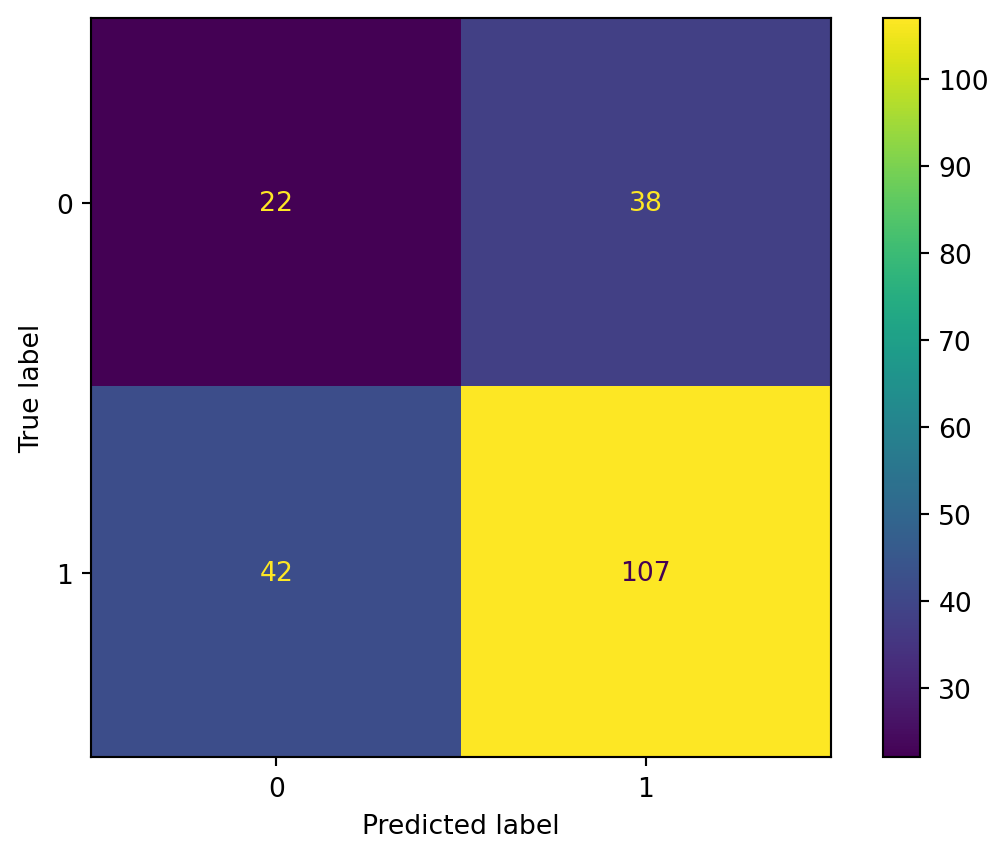

```python
X = df3.drop(["y", "income_new"], axis=1)
# Gender isn't helpful
y = pd.DataFrame(df3["y"])

train_X, test_X, train_y, test_y = train_test_split(X, y, random_state=34)

model = DecisionTreeClassifier(random_state=12)
model.fit(train_X, train_y)

pred = model.predict(test_X)
pred

print(accuracy_score(test_y, pred))
cm = confusion_matrix(test_y, pred)
disp = ConfusionMatrixDisplay(confusion_matrix=cm)
disp.plot()
```

As you can see in the above confusion matrix, there are many more false positives and false negatives than I’d like, making this model not very useful.

Back to top